# Approach to fantasy football and supporters network

Data Access & Regulation - Module II | DAPS&CO - Università degli Studi di Milano

Simone De Luca

01/03/2021

## Introduction

The following is not a project, but a set of ideas to develop. My intention was to look at the world of football, which is not a field of interest for ‘sport analytics’ only, but for sociology, politics and economics too.

My work focused mainly on two questions, which are not directly correlated:

1. the stats of players and teams of Serie A, the first Italian league (on-field performance);
2. the community of supporters and their system of beliefs (off-field creation of meanings).

For the stats of Serie A, I relied on Fantacalcio, the fantasy game of the league. I was facilitated by the availability of excel documents, to which some scraping was added for a descriptive analysis of the results.

For the community of supporters, I explored the use of InstaCrawlR to gather Instagram data following specific keywords in order to create a network analysis of related hashtags in Gephi.

Here, a series of problems have emerged with the functionality of the tool.

### Libraries

```r
library(dplyr)
library(tidyverse)
library(readxl)
library(rvest)
library(kableExtra)
```

## Fantacalcio

```r
setwd("/Users/pc/Desktop/Data access/Capstone-Simone")

url <- "https://www.fantacalcio.it/"

fanta_stat <- read_excel("Data/Statistiche_Fantacalcio_2020-21.xlsx")
fanta_ratings <- read_excel("Data/Quotazioni_Fantacalcio.xlsx")

head(fanta_stat)

#Convert row to column names
colnames(fanta_stat) <- as.character(fanta_stat[1, ])
fanta_stat <- fanta_stat[-1,]

fanta_stat <- as.data.frame(fanta_stat)
str(fanta_stat)

colnames(fanta_ratings) <- as.character(fanta_ratings[1, ])
fanta_ratings <- fanta_ratings[-1,]

fanta_ratings <- as.data.frame(fanta_ratings)
str(fanta_stat)

#Convert data frame column to numeric type
fanta_stat[, c(1,5:18)] <- sapply(fanta_stat[, c(1,5:18)], as.numeric)

fanta_ratings[, c(1,5:7)] <- sapply(fanta_ratings[, c(1,5:7)], as.numeric)
```

### Some descriptive plots

FantaMedia by appearances

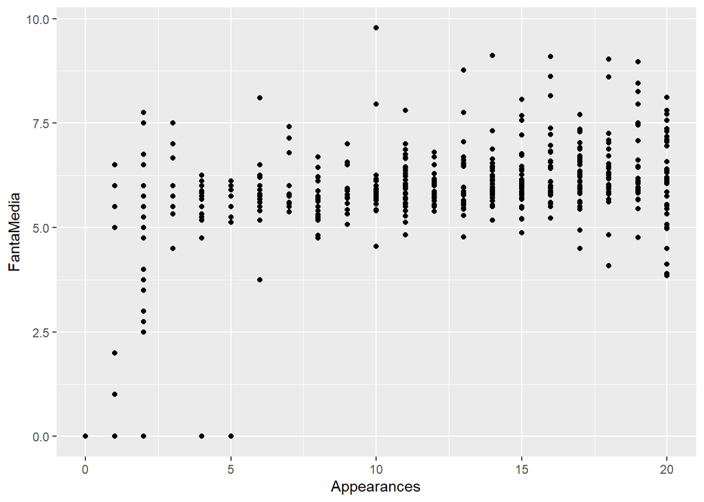

FantaMedia by player position - P (Goalkeeper) D (Defender) C (Midfielder) A (Forward)

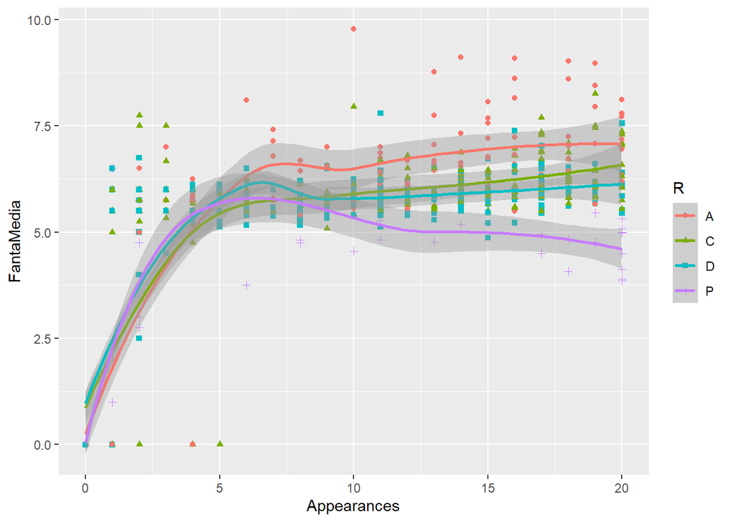

FantaMedia by player position for each team - P (Goalkeeper) D (Defender) C (Midfielder) A (Forward)

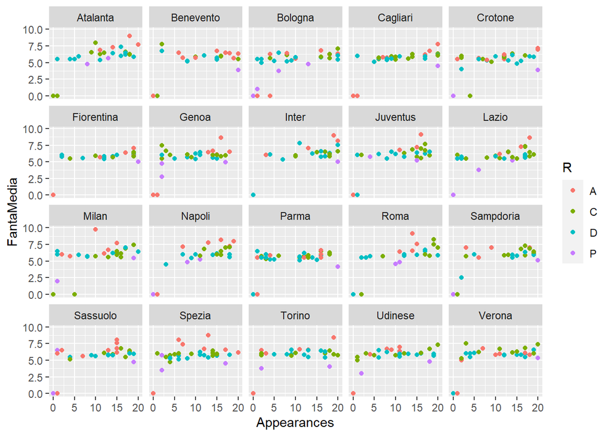

Barplot of observations by positions - P (Goalkeeper) D (Defender) C (Midfielder) A (Forward)

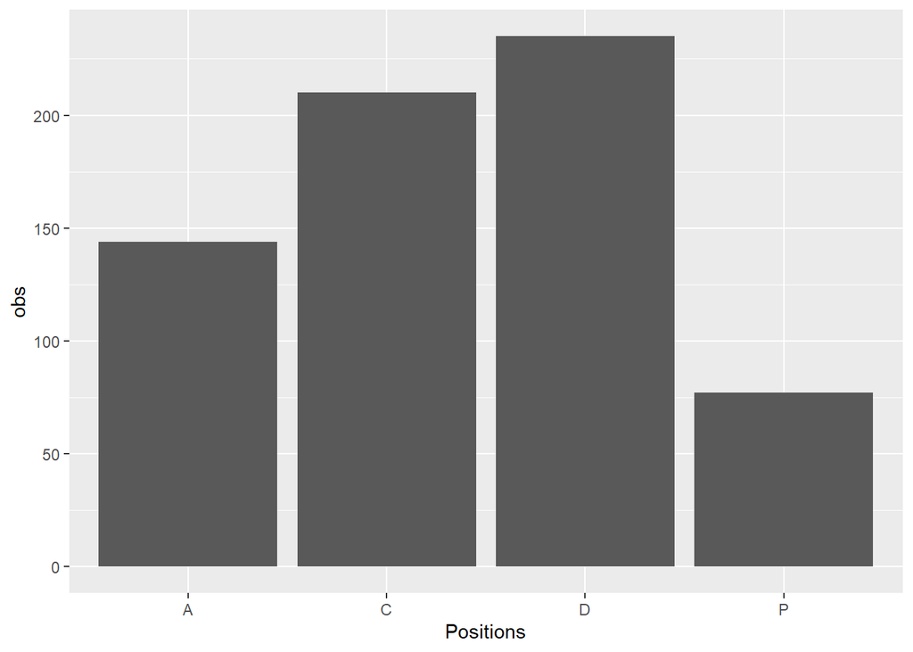

Barplot of FantaMedia by positions - P (Goalkeeper) D (Defender) C (Midfielder) A (Forward)

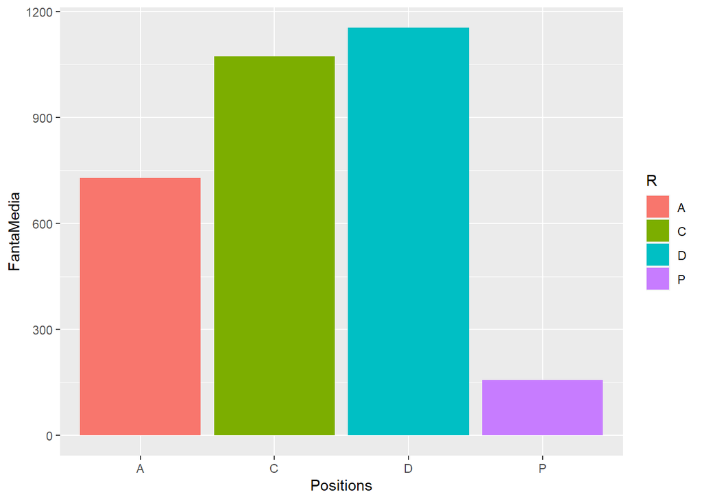

Coxcomb chart of FantaMedia by positions - P (Goalkeeper) D (Defender) C (Midfielder) A (Forward)

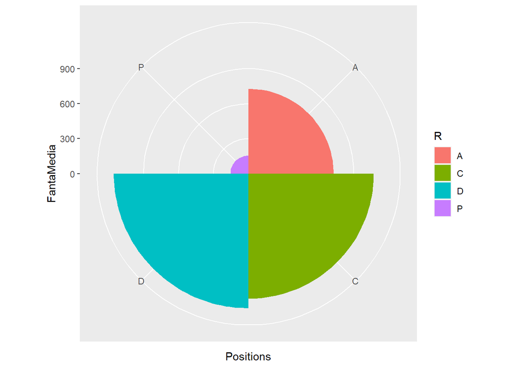

It seems that defenders are the category that make more points, followed by midfielders, forwards and goalkeepers. The result could be related to the number of observations by positions or to the starting line-up, which usually see more defenders and midfielders in the initial 11th.

### Tables

I thought that was useful collecting info about the development of the season. So, I decided to scrape the tables of the league, using the `rvest` package.

```r
standing <- read_html("https://www.fantacalcio.it/serie-a/classifica") %>%
  html_nodes(css = 'table') %>%
  html_table() %>%
  .[[1]]

home_table <- read_html("https://www.fantacalcio.it/serie-a/classifica") %>%
  html_nodes(css = 'table') %>%
  html_table() %>%
  .[[2]]

away_table <- read_html("https://www.fantacalcio.it/serie-a/classifica") %>%
  html_nodes(css = 'table') %>%
  html_table() %>%
  .[[3]]

top_scorers <- read_html("https://www.fantacalcio.it/serie-a/classifica") %>%
  html_nodes(css = 'table') %>%
  html_table() %>%
  .[[4]]
```

This would be the starting point for the analysis. It would be interesting building a predicting model that takes into account the last performances of the players to suggest the optimal starting line-up in comparison with the characteristics of the opponent.

## Supporters network

The idea was to investigate the system of beliefs of the supporters, trying to intercept the social and political issues at the center of their debate. The real interest here was on the world of *ultras*, a very specific galaxy of the universe of supporters. In particular, I was focused on the political affiliations of the different ultras groups and on their relationships.

### Twinning table

[output not shown]

It would be interesting to verify whether there is a correlation between the political affiliation of the ultras and the political orientation of the cities the football clubs represent.

### InstaCrawlR

Then, I moved to social networks in order to parse data related to specific hashtags naming the ultras group. I followed the guide of InstaCrawlR (https://github.com/JonasSchroeder/InstaCrawlR), a tool made of four scripts which is able to collect data from Instagram without API access token.

My intention was to export the lists of related hashtags used by different ultras groups in the same Gephi space to visualize the contact points and differences.

He also managed to get different dataframes: #fedayn, #irriducibili, #barrasbravas, but the forth script (g2gephi.R) stopped to work. Also, Fedra Ippolito tried to run the code, without success.